# SATICA — BOLETÍN DE ALERTAS TEMPRANAS N° 5

## 1. Resumen Ejecutivo de Riesgo

Este resumen presenta el estado actual de las haciendas integradas en el sistema, clasificadas de acuerdo con su evolución estadística en el ciclo calculado. Esta visión permite estratificar el esfuerzo operativo de la corporación desde la respuesta inmediata hasta el seguimiento preventivo.

A continuación se detalla la semaforización oficial del riesgo territorial:

- **CRÍTICO (🔴 Rojo):** Alta probabilidad de ocurrencia inmediata (-1 a +1 mes).
- **ALTO (🟠 Naranja):** Evento inminente/se encuentra rezagado (1 a 2 meses de diferencia).
- **OBSERVACIÓN (🟡 Amarillo):** Alerta Temprana o Seguimiento (2 a 3 meses de diferencia).
- **BAJO (🟢 Verde):** Predio se encuentra sin riesgo estadístico (> -3 meses).
- **MITIGADO (🟢 Verde):** Ciclo Roto. Riesgo desaparece (> +3 meses).

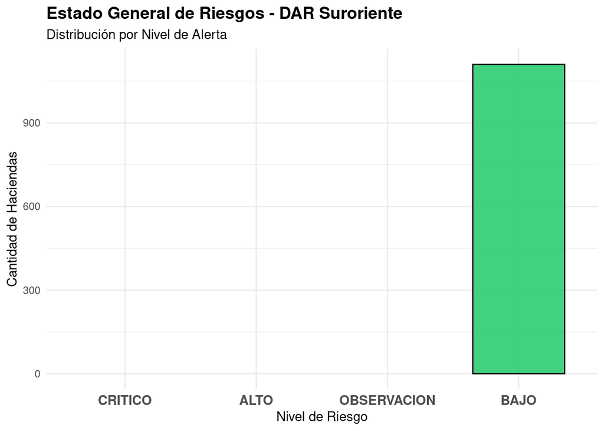

| Nivel de Riesgo | N° de Haciendas |
| --- | --- |
| BAJO | 1110 |

## 2. Cronograma de Alertas Inminentes (Ventana ±15 Días)

Este listado es un cronograma estricto que identifica **únicamente** los predios que se encuentran en la ventana máxima de vulnerabilidad (a 15 días o menos de cumplir su ciclo estimado, o con un rezago máximo de 15 días).

### ✅ No se registran alertas inminentes en la ventana operativa (±15 días) para este ciclo.

## 3. Focalización Operativa (Top 10 por Municipio)

### Municipio: CANDELARIA

| Hacienda | Corregimiento | Ingenio | Riesgo | Último Evento | Historial | Gestión CVC | Coordenadas |
| --- | --- | --- | --- | --- | --- | --- | --- |
| FLORENCIA VALLE_010003 | CABUYAL | INCAUCA | BAJO | Sin Eventos | -Inf | Sin Intervención | 3.3017, -76.377 |
| VERDUM BOTERO_010030 | EL CARMELO | INCAUCA | BAJO | Sin Eventos | -Inf | Sin Intervención | 3.4202, -76.4313 |
| SANTA MARTHA AMALFI_010034 | ARENAL | INCAUCA | BAJO | Sin Eventos | -Inf | Sin Intervención | 3.4188, -76.3675 |
| CECILIA - GARCES UNO_010089 | EL TIPLE | INCAUCA | BAJO | Sin Eventos | -Inf | Sin Intervención | 3.3455, -76.4462 |
| VILLA LUCIA_010101 | CABUYAL | INCAUCA | BAJO | Sin Eventos | -Inf | Sin Intervención | 3.32, -76.3283 |
| SAN CAMILO_010106 | EL TIPLE | INCAUCA | BAJO | Sin Eventos | -Inf | Sin Intervención | 3.3128, -76.414 |
| EL EDEN_010110 | SAN JOAQUIN | INCAUCA | BAJO | Sin Eventos | -Inf | Sin Intervención | 3.3584, -76.4381 |
| ARANJUEZ CAUCA_010130 | EL TIPLE | INCAUCA | BAJO | Sin Eventos | -Inf | Sin Intervención | 3.3421, -76.415 |
| EL MADRONAL - IRMA_010173 | CABUYAL | INCAUCA | BAJO | Sin Eventos | -Inf | Sin Intervención | 3.3401, -76.3753 |
| LAS PALMAS_010197 | EL CARMELO | INCAUCA | BAJO | Sin Eventos | -Inf | Sin Intervención | 3.4322, -76.4231 |

### Municipio: EL CERRITO

| Hacienda | Corregimiento | Ingenio | Riesgo | Último Evento | Historial | Gestión CVC | Coordenadas |
| --- | --- | --- | --- | --- | --- | --- | --- |
| EL TESORO LINCE_011616 | SAN ANTONIO | INCAUCA | BAJO | Sin Eventos | -Inf | Sin Intervención | 3.6635, -76.3445 |
| PORVENIR_002 | EL PLACER | MANUELITA | BAJO | Sin Eventos | -Inf | Sin Intervención | 3.6154, -76.2592 |
| REFLEJO_305 | SAN ANTONIO | MANUELITA | BAJO | Sin Eventos | -Inf | Sin Intervención | 3.6722, -76.3743 |
| SANTA RITA_353 | SAN ANTONIO | MANUELITA | BAJO | Sin Eventos | -Inf | Sin Intervención | 3.6589, -76.3541 |
| SANTA ROSALIA OCTAVIO_389 | SAN ANTONIO | MANUELITA | BAJO | Sin Eventos | -Inf | Sin Intervención | 3.6636, -76.3933 |
| SAN JOAQUIN_442 | SAN ANTONIO | MANUELITA | BAJO | Sin Eventos | -Inf | Sin Intervención | 3.6633, -76.3478 |
| BRISUELAS_302 | SANTA HELENA | MAYAGÜEZ | BAJO | Sin Eventos | -Inf | Sin Intervención | 3.6288, -76.2405 |
| GENOVA_2281 | SAN ANTONIO | PICHICHI | BAJO | Sin Eventos | -Inf | Sin Intervención | 3.6726, -76.3873 |
| EL TREBOL 2_2436 | EL PLACER | PICHICHI | BAJO | Sin Eventos | -Inf | Sin Intervención | 3.649, -76.3578 |
| PROVIDENCIA_080101 | SANTA HELENA | PROVIDENCIA | BAJO | Sin Eventos | -Inf | Sin Intervención | 3.631, -76.2739 |

### Municipio: FLORIDA

| Hacienda | Corregimiento | Ingenio | Riesgo | Último Evento | Historial | Gestión CVC | Coordenadas |
| --- | --- | --- | --- | --- | --- | --- | --- |
| MONTEPALO_010014 | CHOCOCITO | INCAUCA | BAJO | Sin Eventos | -Inf | Sin Intervención | 3.2915, -76.2626 |
| PATIO BONITO LOTE 4_010131 | TARRAGONA | INCAUCA | BAJO | Sin Eventos | -Inf | Sin Intervención | 3.2891, -76.3226 |
| EL REFUGIO 1, 2 Y 3_010139 | CHOCOCITO | INCAUCA | BAJO | Sin Eventos | -Inf | Sin Intervención | 3.2864, -76.2874 |
| PERODIAS YOLANDA_010141 | EL REMOLINO | INCAUCA | BAJO | Sin Eventos | -Inf | Sin Intervención | 3.3039, -76.2595 |
| ESTABLO_010164 | TARRAGONA | INCAUCA | BAJO | Sin Eventos | -Inf | Sin Intervención | 3.2889, -76.3319 |
| ARGENTINA MCH_010230 | TARRAGONA | INCAUCA | BAJO | Sin Eventos | -Inf | Sin Intervención | 3.302, -76.3353 |
| ZUMBAMICO_010251 | EL REMOLINO | INCAUCA | BAJO | Sin Eventos | -Inf | Sin Intervención | 3.3088, -76.2547 |
| PERODIAS DORIS_010252 | EL REMOLINO | INCAUCA | BAJO | Sin Eventos | -Inf | Sin Intervención | 3.3023, -76.2539 |
| PRIMAVERA MANZANO_010262 | TARRAGONA | INCAUCA | BAJO | Sin Eventos | -Inf | Sin Intervención | 3.2895, -76.331 |
| MONTECARLO ESCOBAR_010280 | TARRAGONA | INCAUCA | BAJO | Sin Eventos | -Inf | Sin Intervención | 3.2885, -76.3141 |

### Municipio: PALMIRA

| Hacienda | Corregimiento | Ingenio | Riesgo | Último Evento | Historial | Gestión CVC | Coordenadas |
| --- | --- | --- | --- | --- | --- | --- | --- |
| LA BURRERA TUMACO_1946 | MATAPALO | INCAUCA | BAJO | Sin Eventos | -Inf | Sin Intervención | 3.5885, -76.4266 |
| SAN FELIPE_010374 | AGUACLARA | INCAUCA | BAJO | Sin Eventos | -Inf | Sin Intervención | 3.517, -76.2386 |
| KITSUKA-JULIO_010443 | BOLO - ALIZAL | INCAUCA | BAJO | Sin Eventos | -Inf | Sin Intervención | 3.4747, -76.3976 |
| KITSUKA_010736 | GUANABANAL | INCAUCA | BAJO | Sin Eventos | -Inf | Sin Intervención | 3.4689, -76.4067 |
| SANTA BARBARA TEJADA_011307 | PALMASECA | INCAUCA | BAJO | Sin Eventos | -Inf | Sin Intervención | 3.5201, -76.3245 |
| SHITA_011353 | BOLO - ALIZAL | INCAUCA | BAJO | Sin Eventos | -Inf | Sin Intervención | 3.466, -76.3988 |
| MARAVELEZ_011541 | PALMASECA | INCAUCA | BAJO | Sin Eventos | -Inf | Sin Intervención | 3.5082, -76.4581 |
| MARAVELEZ GUILLERMO_011605 | PALMASECA | INCAUCA | BAJO | Sin Eventos | -Inf | Sin Intervención | 3.5023, -76.4523 |
| GUAIRA BARRIOS_011655 | LA HERRADURA | INCAUCA | BAJO | Sin Eventos | -Inf | Sin Intervención | 3.5484, -76.3974 |
| CONFIN BARRIOS_011656 | LA HERRADURA | INCAUCA | BAJO | Sin Eventos | -Inf | Sin Intervención | 3.5407, -76.3957 |

### Municipio: PRADERA

| Hacienda | Corregimiento | Ingenio | Riesgo | Último Evento | Historial | Gestión CVC | Coordenadas |
| --- | --- | --- | --- | --- | --- | --- | --- |
| LA MICHELA JARAMILLO_011771 | LA FLORESTA | INCAUCA | BAJO | Sin Eventos | -Inf | Sin Intervención | 3.4089, -76.2343 |
| NA_012372 | BOLO - HARTONAL | INCAUCA | BAJO | Sin Eventos | -Inf | Sin Intervención | 3.4164, -76.272 |
| SALSIPUEDES_821 | PARRAGA | LA CABAÑA | BAJO | Sin Eventos | -Inf | Sin Intervención | 3.3681, -76.263 |
| PERGOLA III_847 | PARRAGA | LA CABAÑA | BAJO | Sin Eventos | -Inf | Sin Intervención | 3.3733, -76.2499 |
| VALLECITO_853 | VALLECITO | LA CABAÑA | BAJO | Sin Eventos | -Inf | Sin Intervención | 3.3667, -76.2104 |
| EL TABLON BAJO_B05 | POTRERITO | LA CABAÑA | BAJO | Sin Eventos | -Inf | Sin Intervención | 3.4293, -76.2332 |
| EL TABLON ALTO_B07 | POTRERITO | LA CABAÑA | BAJO | Sin Eventos | -Inf | Sin Intervención | 3.4204, -76.2169 |
| EL BARRANCO_B08 | LA RUIZA | LA CABAÑA | BAJO | Sin Eventos | -Inf | Sin Intervención | 3.4407, -76.2392 |
| AVELINA INDUSTRIAL_0103 | PARRAGA | CENTRAL CASTILLA | BAJO | Sin Eventos | -Inf | Sin Intervención | 3.3643, -76.2813 |
| CASTILLA ORGANICA_0108 | LA TUPIA | CENTRAL CASTILLA | BAJO | Sin Eventos | -Inf | Sin Intervención | 3.3665, -76.2911 |

### Municipio: SIN MUNICIPIO

| Hacienda | Corregimiento | Ingenio | Riesgo | Último Evento | Historial | Gestión CVC | Coordenadas |
| --- | --- | --- | --- | --- | --- | --- | --- |
| LA CLARA_0637 | SIN DATO | CENTRAL CASTILLA | BAJO | Sin Eventos | -Inf | Sin Intervención | 3.2798, -76.258 |
| LA MERCED CABAL HNAS._080500 | SIN DATO | PROVIDENCIA | BAJO | Sin Eventos | -Inf | Sin Intervención | 3.6631, -76.3197 |

## 4. Ficha Detalle Técnica (Top 10 DAR Suroriente)

| Municipio | Hacienda | Ingenio | Nivel | Último Evento | Histórico | Gestión CVC | Coordenadas |
| --- | --- | --- | --- | --- | --- | --- | --- |
| PALMIRA | LA BURRERA TUMACO_1946 | INCAUCA | BAJO | Sin Eventos | -Inf | Sin Intervención | 3.5885, -76.4266 |
| CANDELARIA | FLORENCIA VALLE_010003 | INCAUCA | BAJO | Sin Eventos | -Inf | Sin Intervención | 3.3017, -76.377 |
| FLORIDA | MONTEPALO_010014 | INCAUCA | BAJO | Sin Eventos | -Inf | Sin Intervención | 3.2915, -76.2626 |
| CANDELARIA | VERDUM BOTERO_010030 | INCAUCA | BAJO | Sin Eventos | -Inf | Sin Intervención | 3.4202, -76.4313 |
| CANDELARIA | SANTA MARTHA AMALFI_010034 | INCAUCA | BAJO | Sin Eventos | -Inf | Sin Intervención | 3.4188, -76.3675 |
| CANDELARIA | CECILIA - GARCES UNO_010089 | INCAUCA | BAJO | Sin Eventos | -Inf | Sin Intervención | 3.3455, -76.4462 |
| CANDELARIA | VILLA LUCIA_010101 | INCAUCA | BAJO | Sin Eventos | -Inf | Sin Intervención | 3.32, -76.3283 |
| CANDELARIA | SAN CAMILO_010106 | INCAUCA | BAJO | Sin Eventos | -Inf | Sin Intervención | 3.3128, -76.414 |
| CANDELARIA | EL EDEN_010110 | INCAUCA | BAJO | Sin Eventos | -Inf | Sin Intervención | 3.3584, -76.4381 |
| CANDELARIA | ARANJUEZ CAUCA_010130 | INCAUCA | BAJO | Sin Eventos | -Inf | Sin Intervención | 3.3421, -76.415 |

**Fin del Reporte SATICA**  
*Generado automáticamente por la Dirección Ambiental Regional Suroriente.*  
Fecha de emisión: 30/05/2026 22:55